# Mini Data Analysis Milestone 2

*To complete this milestone, you can either edit [this `.rmd` file](https://raw.githubusercontent.com/UBC-STAT/stat545.stat.ubc.ca/master/content/mini-project/mini-project-2.Rmd) directly. Fill in the sections that are commented out with `<!--- start your work here--->`. When you are done, make sure to knit to an `.md` file by changing the output in the YAML header to `github_document`, before submitting a tagged release on canvas.*

# Welcome to the rest of your mini data analysis project!

In Milestone 1, you explored your data. and came up with research questions. This time, we will finish up our mini data analysis and obtain results for your data by:

- Making summary tables and graphs
- Manipulating special data types in R: factors and/or dates and times.
- Fitting a model object to your data, and extract a result.
- Reading and writing data as separate files.

We will also explore more in depth the concept of *tidy data.*

**NOTE**: The main purpose of the mini data analysis is to integrate what you learn in class in an analysis. Although each milestone provides a framework for you to conduct your analysis, it’s possible that you might find the instructions too rigid for your data set. If this is the case, you may deviate from the instructions – just make sure you’re demonstrating a wide range of tools and techniques taught in this class.

# Instructions

**To complete this milestone**, edit [this very `.Rmd` file](https://raw.githubusercontent.com/UBC-STAT/stat545.stat.ubc.ca/master/content/mini-project/mini-project-2.Rmd) directly. Fill in the sections that are tagged with `<!--- start your work here--->`.

**To submit this milestone**, make sure to knit this `.Rmd` file to an `.md` file by changing the YAML output settings from `output: html_document` to `output: github_document`. Commit and push all of your work to your mini-analysis GitHub repository, and tag a release on GitHub. Then, submit a link to your tagged release on canvas.

**Points**: This milestone is worth 50 points: 45 for your analysis, and 5 for overall reproducibility, cleanliness, and coherence of the Github submission.

**Research Questions**: In Milestone 1, you chose two research questions to focus on. Wherever realistic, your work in this milestone should relate to these research questions whenever we ask for justification behind your work. In the case that some tasks in this milestone don’t align well with one of your research questions, feel free to discuss your results in the context of a different research question.

# Learning Objectives

By the end of this milestone, you should:

- Understand what *tidy* data is, and how to create it using `tidyr`.
- Generate a reproducible and clear report using R Markdown.
- Manipulating special data types in R: factors and/or dates and times.
- Fitting a model object to your data, and extract a result.
- Reading and writing data as separate files.

# Setup

Begin by loading your data and the tidyverse package below:

```r
library(datateachr) # <- might contain the data you picked!
library(tidyverse)
```

# Task 1: Process and summarize your data

From milestone 1, you should have an idea of the basic structure of your dataset (e.g. number of rows and columns, class types, etc.). Here, we will start investigating your data more in-depth using various data manipulation functions.

### 1.1 (1 point)

First, write out the 4 research questions you defined in milestone 1 were. This will guide your work through milestone 2:

**Research Question 1:** How does the original_price of games vary with their release_date and game types? Specifically, is there a trend in the pricing of games over time, and do different game types exhibit distinct pricing patterns?

**Research Question 2:** Is the presence or absence of a discount associated with the release_date of games?

**Research Question 3:** Is the magnitude of the price_difference between the original and discounted prices correlated with the original_price of games?

**Research Question 4:** Is there a relationship between the genre of games and their release_date?

Here, we will investigate your data using various data manipulation and graphing functions.

### 1.2 (8 points)

Now, for each of your four research questions, choose one task from options 1-4 (summarizing), and one other task from 4-8 (graphing). You should have 2 tasks done for each research question (8 total). Make sure it makes sense to do them! (e.g. don’t use a numerical variables for a task that needs a categorical variable.). Comment on why each task helps (or doesn’t!) answer the corresponding research question.

Ensure that the output of each operation is printed!

Also make sure that you’re using dplyr and ggplot2 rather than base R. Outside of this project, you may find that you prefer using base R functions for certain tasks, and that’s just fine! But part of this project is for you to practice the tools we learned in class, which is dplyr and ggplot2.

**Summarizing:**

1. Compute the *range*, *mean*, and *two other summary statistics* of **one numerical variable** across the groups of **one categorical variable** from your data.
2. Compute the number of observations for at least one of your categorical variables. Do not use the function `table()`!
3. Create a categorical variable with 3 or more groups from an existing numerical variable. You can use this new variable in the other tasks! *An example: age in years into “child, teen, adult, senior”.*
4. Compute the proportion and counts in each category of one categorical variable across the groups of another categorical variable from your data. Do not use the function `table()`!

**Graphing:**

6. Create a graph of your choosing, make one of the axes logarithmic, and format the axes labels so that they are “pretty” or easier to read.
7. Make a graph where it makes sense to customize the alpha transparency.

Using variables and/or tables you made in one of the “Summarizing” tasks:

8. Create a graph that has at least two geom layers.
9. Create 3 histograms, with each histogram having different sized bins. Pick the “best” one and explain why it is the best.

Make sure it’s clear what research question you are doing each operation for!

**Pre-processing** To enhance analysis efficiency due to the dataset’s extensive volume, we simplified the data by retaining only the primary genre for each game and focusing on the release year, effectively streamlining and compressing the information without losing essential insights. Games with exceptionally high prices were excluded from the analysis to ensure the data’s integrity and to focus on more typical pricing trends in the gaming industry.

```r
# exclude unreasonable price
filtered_games <- steam_games %>%
  filter(original_price <= 1000)
# Modify the 'genre' column to only keep the text before the first comma
filtered_games$genre <- sapply(strsplit(as.character(filtered_games$genre), ","), `[`, 1)
head(filtered_games)
```

```
## # A tibble: 6 × 21
##      id url     types name  desc_snippet recent_reviews all_reviews release_date
##   <dbl> <chr>   <chr> <chr> <chr>        <chr>          <chr>       <chr>
## 1     1 https:… app   DOOM  Now include… Very Positive… Very Posit… May 12, 2016
## 2     2 https:… app   PLAY… PLAYERUNKNO… Mixed,(6,214)… Mixed,(836… Dec 21, 2017
## 3     3 https:… app   BATT… Take comman… Mixed,(166),-… Mostly Pos… Apr 24, 2018
## 4     4 https:… app   DayZ  The post-so… Mixed,(932),-… Mixed,(167… Dec 13, 2018
## 5     5 https:… app   EVE … EVE Online … Mixed,(287),-… Mostly Pos… May 6, 2003
## 6     7 https:… app   Devi… The ultimat… Very Positive… Very Posit… Mar 7, 2019
## # ℹ 13 more variables: developer <chr>, publisher <chr>, popular_tags <chr>,
## #   game_details <chr>, languages <chr>, achievements <dbl>, genre <chr>,
## #   game_description <chr>, mature_content <chr>, minimum_requirements <chr>,
## #   recommended_requirements <chr>, original_price <dbl>, discount_price <dbl>
```

```r
# Extract the year from the 'release_date' column
filtered_games$release_year <- as.numeric(format(as.Date(filtered_games$release_date, format="%b %d, %Y"), "%Y"))
```

**Research Question 1**: How does the original price of games vary with their release date and game type? **Option 1 (summarizing)** Calculating summary statistics provides a deeper insight into data distribution. This helps identify the pricing characteristics of different game genres and allows for a comprehensive understanding of how game prices have varied across genres. Approach: Calculate the range, mean, median, and standard deviation of the original price across different game genres.

```r
summary_by_genre <- filtered_games %>%
  group_by(genre) %>%
  summarise(
    price_range = paste0("[", min(original_price, na.rm = TRUE), ", ", max(original_price, na.rm = TRUE), "]"),
    mean_price = mean(original_price, na.rm = TRUE),
    median_price = median(original_price, na.rm = TRUE),
    sd_price = sd(original_price, na.rm = TRUE)
  )

print(summary_by_genre)
```

```
## # A tibble: 30 × 5
##    genre                 price_range mean_price median_price sd_price
##    <chr>                 <chr>            <dbl>        <dbl>    <dbl>
##  1 Accounting            [0, 79.99]       20.8         12.5     30.1
##  2 Action                [0, 624.74]      12.1          4.99    41.7
##  3 Adventure             [0, 624.74]      18.6          4.99    66.7
##  4 Animation & Modeling  [0, 995]         51.6         20.0    102.
##  5 Audio Production      [0, 528.99]      66.3         20.0    118.
##  6 Casual                [0, 624.74]      12.0          2.99    47.7
##  7 Design & Illustration [0, 199]         18.5         13.0     22.4
##  8 Early Access          [0, 16.99]        8.39         9.99     6.34
##  9 Education             [0, 149.99]      14.9          7.99    23.3
## 10 Free to Play          [0, 499.99]      11.5          0       33.4
## # ℹ 20 more rows
```

**Option 6 (graphing)** Graphical representation can help us understand the trend of prices over time intuitively. Given that the price data might span a wide range, using a logarithmic axis can better depict data distribution, especially when outliers or extreme values are present. Approach: Create a scatter plot displaying how the original price varies over time, with the price axis set to a logarithmic scale.

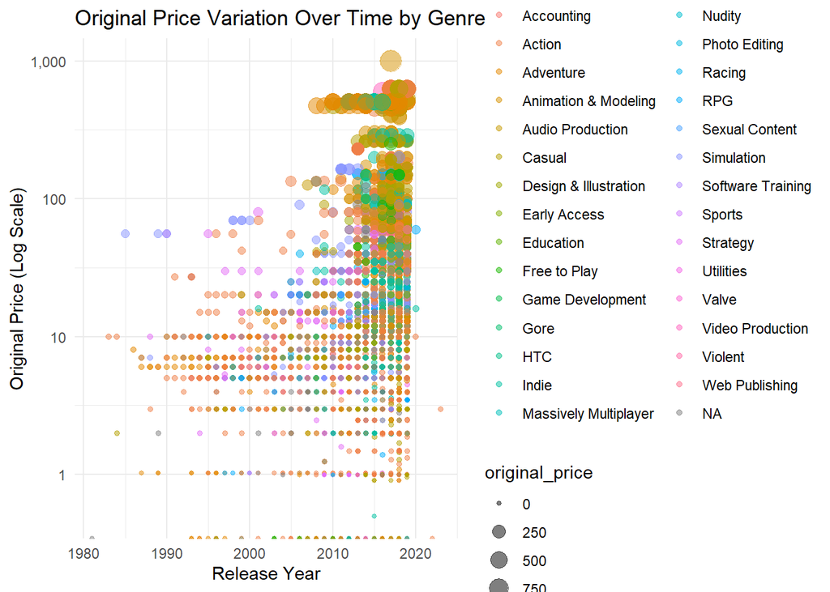

```r
# Create a scatter plot displaying original price variation over time
ggplot(filtered_games, aes(x=release_year, y=original_price, color=genre)) +
  geom_point(aes(size=original_price), alpha=0.5) +
  scale_y_log10(labels = scales::comma) +
  labs(title="Original Price Variation Over Time by Genre", x="Release Year", y="Original Price (Log Scale)") +
  theme_minimal() +
  theme(legend.position="right")
```

**Research Question 2**: Is the presence or absence of a discount associated with the release date of games? **Option 2 (summarizing)** Computing the number of observations for a categorical variable, in this case, the presence or absence of a discount, can give us a clear count of how many games are discounted each year. This will provide a direct measure of the trend of discounts over time. Approach: Calculate the number of discounted and non-discounted games for each release year.

```r
# Add a column to indicate if a game has a discount or not
filtered_games$has_discount <- ifelse(is.na(filtered_games$discount_price), "No", "Yes")

# Calculate the number of discounted and non-discounted games for each release year
discount_summary <- filtered_games %>%
  group_by(release_year, has_discount) %>%
  summarise(count = n())
print(discount_summary)
```

```
## # A tibble: 75 × 3
## # Groups:   release_year [42]
##    release_year has_discount count
##           <dbl> <chr>        <int>
##  1         1981 No               1
##  2         1983 No               1
##  3         1984 No               2
##  4         1985 Yes              1
##  5         1986 No               1
##  6         1987 No               3
##  7         1987 Yes              1
##  8         1988 No               5
##  9         1989 No               1
## 10         1989 Yes              5
## # ℹ 65 more rows
```

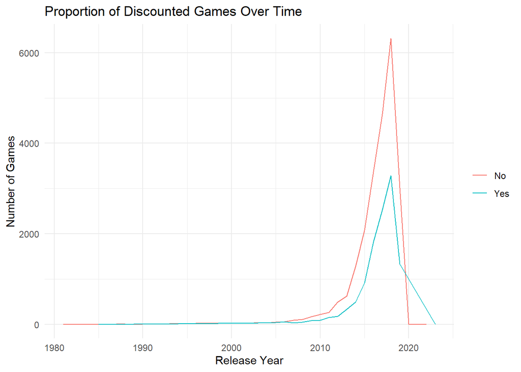

```r
# Create a line plot displaying the proportion of games that received a discount over time
ggplot(discount_summary, aes(x=release_year, y=count, color=has_discount, group=has_discount)) +
  geom_line() +
  labs(title="Proportion of Discounted Games Over Time", x="Release Year", y="Number of Games") +
  theme_minimal() +
  theme(legend.title=element_blank())
```

```r
# Compute the price difference between original and discounted prices
filtered_games$price_difference <- filtered_games$original_price - filtered_games$discount_price

# Calculate average price difference for various ranges of original prices
price_difference_summary <- filtered_games %>%
  filter(!is.na(price_difference)) %>%
  group_by(original_price) %>%
  summarise(average_difference = mean(price_difference, na.rm = TRUE))

print(price_difference_summary)
```

```
## # A tibble: 352 × 2
##    original_price average_difference
##             <dbl>              <dbl>
##  1           0               -48.8
##  2           0.9               0.32
##  3           0.99            -25.4
##  4           1                -2.39
##  5           1.02           -905.
##  6           1.09            -13.9
##  7           1.29             -4.03
##  8           1.49            -81.6
##  9           1.98              0.910
## 10           1.99            -35.7
## # ℹ 342 more rows
```

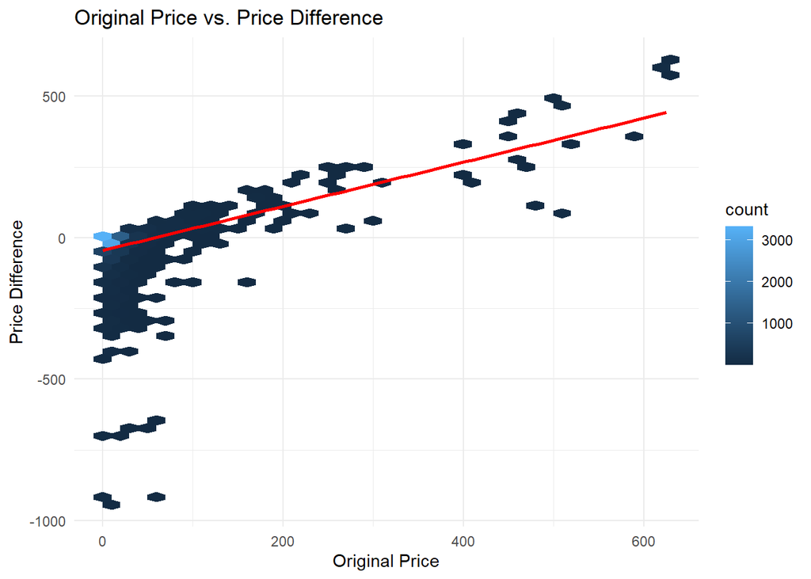

```r
ggplot(filtered_games, aes(x=original_price, y=price_difference)) +
  geom_hex(bins = 50) +
  geom_smooth(method = "lm", se = FALSE, color = "red") +  # Regression trend line
  labs(title="Original Price vs. Price Difference", x="Original Price", y="Price Difference") +
  theme_minimal()
```

**Research Question 4**: Is there a relationship between the genre of games and their release date? **Option 1 (summarizing)** Calculating the number of games per genre for each release year gives a clear quantitative view of which genres were predominant in which years. Approach: For each release year, count the number of games for each genre.

```r
# Calculate the number of games of each genre for each release year
genre_year_summary <- filtered_games %>%
  group_by(release_year, genre) %>%
  summarise(count = n())
print(genre_year_summary)
```

```
## # A tibble: 374 × 3
## # Groups:   release_year [42]
##    release_year genre      count
##           <dbl> <chr>      <int>
##  1         1981 <NA>           1
##  2         1983 Action         1
##  3         1984 Action         1
##  4         1984 Casual         1
##  5         1985 Simulation     1
##  6         1986 Adventure      1
##  7         1987 Adventure      3
##  8         1987 Simulation     1
##  9         1988 Action         1
## 10         1988 Adventure      2
## # ℹ 364 more rows
```

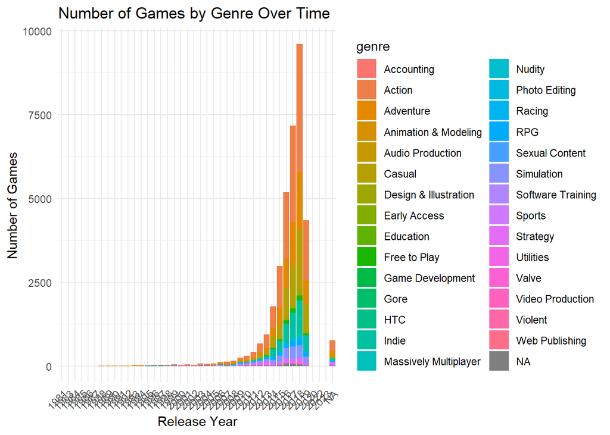

```r
# Create a stacked bar plot displaying the number of games of each genre over time
ggplot(genre_year_summary, aes(x=as.factor(release_year), y=count, fill=genre)) +
  geom_bar(stat="identity") +
  labs(title="Number of Games by Genre Over Time", x="Release Year", y="Number of Games") +
  theme_minimal() +
  theme(axis.text.x=element_text(angle=45, hjust=1))
```

### 1.3 (2 points)

Based on the operations that you’ve completed, how much closer are you to answering your research questions? Think about what aspects of your research questions remain unclear. Can your research questions be refined, now that you’ve investigated your data a bit more? Which research questions are yielding interesting results?

Based on the analyses conducted, I believe we have obtained pertinent answers to all our research questions. For Research Question 1, it’s evident that as the years have progressed, the prices of games have surged. Furthermore, there’s a noticeable correlation between the genre of games and their prices. In recent years, more expensive games tend to belong to similar genres, suggesting a trend in the market’s preference or production costs associated with these genres.Regarding Research Question 2, our findings are quite enlightening. The peaks of games with and without discounts occurring in the same years can lead us to deduce that games are likely to be offered at a discount after being on the market for a certain duration. This observation aligns with the typical promotional strategies employed by game developers or platforms to rejuvenate the sales of older titles. As for Research Question 3, the correlation between a game’s original price and the magnitude of its discount is insightful. While it’s logical to see that pricier games have more substantial absolute discounts, the trend doesn’t strictly follow a linear y=x relationship. This suggests that while more expensive games are discounted, their relative discount rate isn’t necessarily higher. This could be indicative of a strategic balance that game developers strike: enticing potential buyers with discounts while ensuring optimal profits. Lastly, in Research Question 4, the data showcases an exponential increase in the number of games being released annually. Genres like action and adventure are notably at the forefront of this surge. The increasing dominance of these genres in the gaming market might be indicative of evolving player preferences or the profitability of these genres. In conclusion, the analyses have furnished us with valuable insights into the gaming industry’s trends, from pricing strategies to genre preferences. These findings not only provide a snapshot of the current state but also hint at the industry’s possible future trajectory.

# Task 2: Tidy your data

In this task, we will do several exercises to reshape our data. The goal here is to understand how to do this reshaping with the `tidyr` package.

A reminder of the definition of *tidy* data:

- Each row is an **observation**
- Each column is a **variable**
- Each cell is a **value**

### 2.1 (2 points)

Based on the definition above, can you identify if your data is tidy or untidy? Go through all your columns, or if you have >8 variables, just pick 8, and explain whether the data is untidy or tidy.

**check if tidy**: By using glimpse() function and then I select 8 col.

```r
glimpse(steam_games)
```

```
## Rows: 40,833
## Columns: 21
## $ id                       <dbl> 1, 2, 3, 4, 5, 6, 7, 8, 9, 10, 11, 12, 13, 14…
## $ url                      <chr> "https://store.steampowered.com/app/379720/DO…
## $ types                    <chr> "app", "app", "app", "app", "app", "bundle", …
## $ name                     <chr> "DOOM", "PLAYERUNKNOWN'S BATTLEGROUNDS", "BAT…
## $ desc_snippet             <chr> "Now includes all three premium DLC packs (Un…
## $ recent_reviews           <chr> "Very Positive,(554),- 89% of the 554 user re…
## $ all_reviews              <chr> "Very Positive,(42,550),- 92% of the 42,550 u…
## $ release_date             <chr> "May 12, 2016", "Dec 21, 2017", "Apr 24, 2018…
## $ developer                <chr> "id Software", "PUBG Corporation", "Harebrain…
## $ publisher                <chr> "Bethesda Softworks,Bethesda Softworks", "PUB…
## $ popular_tags             <chr> "FPS,Gore,Action,Demons,Shooter,First-Person,…
## $ game_details             <chr> "Single-player,Multi-player,Co-op,Steam Achie…
## $ languages                <chr> "English,French,Italian,German,Spanish - Spai…
## $ achievements             <dbl> 54, 37, 128, NA, NA, NA, 51, 55, 34, 43, 72, …
## $ genre                    <chr> "Action", "Action,Adventure,Massively Multipl…
## $ game_description         <chr> "About This Game Developed by id software, th…
## $ mature_content           <chr> NA, "Mature Content Description  The develope…
## $ minimum_requirements     <chr> "Minimum:,OS:,Windows 7/8.1/10 (64-bit versio…
## $ recommended_requirements <chr> "Recommended:,OS:,Windows 7/8.1/10 (64-bit ve…
## $ original_price           <dbl> 19.99, 29.99, 39.99, 44.99, 0.00, NA, 59.99, …
## $ discount_price           <dbl> 14.99, NA, NA, NA, NA, 35.18, 70.42, 17.58, N…
```

```r
selected_columns <- filtered_games %>% select(id, types, genre, release_date, developer, publisher, original_price, discount_price)
glimpse(selected_columns)
```

```
## Rows: 35,478
## Columns: 8
## $ id             <dbl> 1, 2, 3, 4, 5, 7, 8, 9, 10, 11, 12, 13, 14, 15, 17, 18,…
## $ types          <chr> "app", "app", "app", "app", "app", "app", "app", "app",…
## $ genre          <chr> "Action", "Action", "Action", "Action", "Action", "Acti…
## $ release_date   <chr> "May 12, 2016", "Dec 21, 2017", "Apr 24, 2018", "Dec 13…
## $ developer      <chr> "id Software", "PUBG Corporation", "Harebrained Schemes…
## $ publisher      <chr> "Bethesda Softworks,Bethesda Softworks", "PUBG Corporat…
## $ original_price <dbl> 19.99, 29.99, 39.99, 44.99, 0.00, 59.99, 14.99, 29.99, …
## $ discount_price <dbl> 14.99, NA, NA, NA, NA, 70.42, 17.58, NA, NA, NA, 59.97,…
```

If the dataset have missing values, it is untiy. Check my dataset by this rule.

```r
missing_value <- sum(is.na(selected_columns))
if (missing_value > 0) {
  cat("Missing values exist! The dataset is untidy")
} else {
  cat("No missing values found!")
}
```

```
## Missing values exist! The dataset is untidy
```

### 2.2 (4 points)

Now, if your data is tidy, untidy it! Then, tidy it back to it’s original state.

If your data is untidy, then tidy it! Then, untidy it back to it’s original state.

Be sure to explain your reasoning for this task. Show us the “before” and “after”.

**Original data**

```r
missing_value <- sum(is.na(selected_columns))
if (missing_value > 0) {
  cat("Missing values exist! The dataset is untidy")
} else {
  cat("No missing values found!")
}
```

```
## Missing values exist! The dataset is untidy
```

**Tidy data**

```r
NA_columns <- selected_columns %>%
  summarise_all(~sum(is.na(.))) %>%
  as.logical()
names(selected_columns)[NA_columns]
```

```
## [1] "types"          "genre"          "release_date"   "developer"
## [5] "publisher"      "discount_price"
```

```r
backup_data <- selected_columns
selected_columns_clean <- selected_columns %>% drop_na()
```

**Check**

```r
missing_value <- sum(is.na(selected_columns_clean))
if (missing_value > 0) {
  cat("Missing values exist! The dataset is untidy")
} else {
  cat("No missing values found!")
}
```

```
## No missing values found!
```

**Restore data**

```r
restored_data <- backup_data
```

**Check**

```r
missing_value <- sum(is.na(restored_data))
if (missing_value > 0) {
  cat("Missing values exist! The dataset is untidy")
} else {
  cat("No missing values found!")
}
```

```
## Missing values exist! The dataset is untidy
```

### 2.3 (4 points)

Now, you should be more familiar with your data, and also have made progress in answering your research questions. Based on your interest, and your analyses, pick 2 of the 4 research questions to continue your analysis in the remaining tasks:

1. *Research Question 1*: Is the presence or absence of a discount associated with the release_date of games?
2. *Research Question 2*: Is there a relationship between the genre of games and their release_date?

Explain your decision for choosing the above two research questions.

I chose these two questions because they convey a wealth of information within a specific time frame. For Research Question 1, the presence or absence of discounts experienced a significant fluctuation between the years 2010 and 2023. Similarly, for Research Question 2, certain game genres have seen a dramatic increase in recent years.

Now, try to choose a version of your data that you think will be appropriate to answer these 2 questions. Use between 4 and 8 functions that we’ve covered so far (i.e. by filtering, cleaning, tidy’ing, dropping irrelevant columns, etc.).

(If it makes more sense, then you can make/pick two versions of your data, one for each research question.)

```r
# Filtering
relevant_data <- filtered_games %>% filter(release_year >= 2010 & release_year <= 2023)
relevant_data$genre <- sapply(strsplit(as.character(relevant_data$genre), ","), `[`, 1)
relevant_data$release_year <- as.numeric(format(as.Date(relevant_data$release_date, format="%b %d, %Y"), "%Y"))
# Creating a New Column
relevant_data$has_discount <- ifelse(is.na(relevant_data$discount_price), 0, 1)

# Cleaning
relevant_data_clean <- relevant_data %>% drop_na(c(release_year, genre, has_discount))

# Dropping Irrelevant Columns
selected_data <- relevant_data_clean %>% select(id, release_year, genre, original_price, discount_price, has_discount)

# Tidying
selected_data$genre <- str_extract(selected_data$genre, "^[^,]+")

# Grouping and Summarizing
genre_year_summary <- selected_data %>% group_by(release_year, genre) %>% summarise(count = n(), .groups = "drop")

selected_data
```

```
## # A tibble: 33,112 × 6
##       id release_year genre     original_price discount_price has_discount
##    <dbl>        <dbl> <chr>              <dbl>          <dbl>        <dbl>
##  1     1         2016 Action              20.0           15.0            1
##  2     2         2017 Action              30.0           NA              0
##  3     3         2018 Action              40.0           NA              0
##  4     4         2018 Action              45.0           NA              0
##  5     7         2019 Action              60.0           70.4            1
##  6     8         2016 Adventure           15.0           17.6            1
##  7     9         2017 Strategy            30.0           NA              0
##  8    10         2019 Action              50.0           NA              0
##  9    11         2018 Adventure           20.0           NA              0
## 10    12         2017 Adventure           40.0           60.0            1
## # ℹ 33,102 more rows
```

# Task 3: Modelling

## 3.0 (no points)

Pick a research question from 1.2, and pick a variable of interest (we’ll call it “Y”) that’s relevant to the research question. Indicate these.

**Research Question**: Is there a relationship between the genre of games and their release_date?

## 3.1 (3 points)

Fit a model or run a hypothesis test that provides insight on this variable with respect to the research question. Store the model object as a variable, and print its output to screen. We’ll omit having to justify your choice, because we don’t expect you to know about model specifics in STAT 545.

- **Note**: It’s OK if you don’t know how these models/tests work. Here are some examples of things you can do here, but the sky’s the limit.
  - You could fit a model that makes predictions on Y using another variable, by using the `lm()` function.
  - You could test whether the mean of Y equals 0 using `t.test()`, or maybe the mean across two groups are different using `t.test()`, or maybe the mean across multiple groups are different using `anova()` (you may have to pivot your data for the latter two).
  - You could use `lm()` to test for significance of regression coefficients.

Since the genre is a categorical variable with potentially many levels, I want to use an ANOVA to check if there’s a significant difference in the release years across different genres.

```r
genre_model <- lm(release_year ~ genre, data = selected_data)
anova_genre <- anova(genre_model)
print(anova_genre)
```

```
## Analysis of Variance Table
##
## Response: release_year
##              Df Sum Sq Mean Sq F value    Pr(>F)
## genre        24   4536 189.011  55.308 < 2.2e-16 ***
## Residuals 33087 113072   3.417
## ---
## Signif. codes:  0 '***' 0.001 '**' 0.01 '*' 0.05 '.' 0.1 ' ' 1
```

## 3.2 (3 points)

Produce something relevant from your fitted model: either predictions on Y, or a single value like a regression coefficient or a p-value.

- Be sure to indicate in writing what you chose to produce.
- Your code should either output a tibble (in which case you should indicate the column that contains the thing you’re looking for), or the thing you’re looking for itself.
- Obtain your results using the `broom` package if possible. If your model is not compatible with the broom function you’re needing, then you can obtain your results by some other means, but first indicate which broom function is not compatible.

*the coefficients of the linear model*

```r
library(broom)
tidied_output <- tidy(genre_model)
tidied_output
```

```
## # A tibble: 25 × 5
##    term                       estimate std.error statistic p.value
##    <chr>                         <dbl>     <dbl>     <dbl>   <dbl>
##  1 (Intercept)                2017.        0.755 2673.       0
##  2 genreAction                  -0.778     0.755   -1.03     0.303
##  3 genreAdventure               -0.670     0.755   -0.888    0.375
##  4 genreAnimation & Modeling    -0.754     0.766   -0.984    0.325
##  5 genreAudio Production        -0.488     0.781   -0.626    0.532
##  6 genreCasual                  -0.581     0.755   -0.770    0.441
##  7 genreDesign & Illustration   -0.547     0.760   -0.720    0.472
##  8 genreEarly Access            -0.100     1.12    -0.0893   0.929
##  9 genreEducation               -0.552     0.784   -0.704    0.481
## 10 genreFree to Play            -0.773     0.759   -1.02     0.309
## # ℹ 15 more rows
```

```r
y_data <- augment(genre_model)
head(y_data)
```

```
## # A tibble: 6 × 8
##   release_year genre     .fitted .resid      .hat .sigma      .cooksd .std.resid
##          <dbl> <chr>       <dbl>  <dbl>     <dbl>  <dbl>        <dbl>      <dbl>
## 1         2016 Action      2017. -0.722 0.0000751   1.85 0.000000459      -0.391
## 2         2017 Action      2017.  0.278 0.0000751   1.85 0.0000000678      0.150
## 3         2018 Action      2017.  1.28  0.0000751   1.85 0.00000144        0.691
## 4         2018 Action      2017.  1.28  0.0000751   1.85 0.00000144        0.691
## 5         2019 Action      2017.  2.28  0.0000751   1.85 0.00000456        1.23
## 6         2016 Adventure   2017. -0.830 0.000185    1.85 0.00000149       -0.449
```

# Task 4: Reading and writing data

Get set up for this exercise by making a folder called `output` in the top level of your project folder / repository. You’ll be saving things there.

## 4.1 (3 points)

Take a summary table that you made from Task 1, and write it as a csv file in your `output` folder. Use the `here::here()` function.

- **Robustness criteria**: You should be able to move your Mini Project repository / project folder to some other location on your computer, or move this very Rmd file to another location within your project repository / folder, and your code should still work.
- **Reproducibility criteria**: You should be able to delete the csv file, and remake it simply by knitting this Rmd file.

```r
library(here)
file_path <- here("output", "summary_table.csv")
write.csv(summary_by_genre, file = file_path, row.names = FALSE)
```

## 4.2 (3 points)

Write your model object from Task 3 to an R binary file (an RDS), and load it again. Be sure to save the binary file in your `output` folder. Use the functions `saveRDS()` and `readRDS()`.

- The same robustness and reproducibility criteria as in 4.1 apply here.

```r
#save model
file_path <- here("output", "genre_model.rds")
saveRDS(genre_model, file = file_path)

#load model
genre_model <- readRDS(file_path)
```

# Overall Reproducibility/Cleanliness/Coherence Checklist

Here are the criteria we’re looking for.

## Coherence (0.5 points)

The document should read sensibly from top to bottom, with no major continuity errors.

The README file should still satisfy the criteria from the last milestone, i.e. it has been updated to match the changes to the repository made in this milestone.

## File and folder structure (1 points)

You should have at least three folders in the top level of your repository: one for each milestone, and one output folder. If there are any other folders, these are explained in the main README.

Each milestone document is contained in its respective folder, and nowhere else.

Every level-1 folder (that is, the ones stored in the top level, like “Milestone1” and “output”) has a `README` file, explaining in a sentence or two what is in the folder, in plain language (it’s enough to say something like “This folder contains the source for Milestone 1”).

## Output (1 point)

All output is recent and relevant:

- All Rmd files have been `knit`ted to their output md files.
- All knitted md files are viewable without errors on Github. Examples of errors: Missing plots, “Sorry about that, but we can’t show files that are this big right now” messages, error messages from broken R code
- All of these output files are up-to-date – that is, they haven’t fallen behind after the source (Rmd) files have been updated.
- There should be no relic output files. For example, if you were knitting an Rmd to html, but then changed the output to be only a markdown file, then the html file is a relic and should be deleted.

Our recommendation: delete all output files, and re-knit each milestone’s Rmd file, so that everything is up to date and relevant.

## Tagged release (0.5 point)

You’ve tagged a release for Milestone 2.

### Attribution

Thanks to Victor Yuan for mostly putting this together.